# 21 Power Analysis for OLS Regression

## 23.1 The `pwrss.f.reg` function

We will start our power analysis using the The `pwrss.f.reg` function for one predictor in an OLS regression, with our given observations of n = 32 and $R^2$ = .75. Given these values, we are expecting that one variable (WT) explains 75% of the variance in the outcome or Miles per gallon (R2=0.75 or r2 = 0.75 in the code)<sup>2</sup>.

```r
RegOne_lm <- pwrss.f.reg(
  r2 = 0.75,
  k = 1,
  n = 32,
  power = NULL,
  alpha = 0.05
)
 Linear Regression (F test)
 R-squared Deviation from 0 (zero)
 H0: r2 = 0
 HA: r2 > 0
 ------------------------------
  Statistical power = 1
  n = 32
 ------------------------------
 Numerator degrees of freedom = 1
 Denominator degrees of freedom = 30
 Non-centrality parameter = 96
 Type I error rate = 0.05
 Type II error rate = 0
RegOne_lm$power
[1] 1
```

Given the information provided, we get 100% power. Our effect size of r2 = 0.75 is considered a large effect provided the following guidelines by Cohen (1988)<sup>3</sup>

$f^2$ = 0.02 indicates a small effect;

$f^2$ = 0.15 indicates a medium effect;

$f^2$ = 0.35 indicates a large effect.

We will use these guidelines to continue our exploration. We will concentrate on a fixed medium effect size. Where, the paired correlation is approximately r = .40 for a medium correlation and for an $f^2$ or effect size of 0.15. using this fixed effect, we will look at various sample sizes to obtain power of 80% or greater given a medium effect size. In our sequence of possible sample sizes, the minimum n = 1 as n > p(p+1)/2 = 1(2)/2 = 1

```r
OLSReg_df <- tibble(n = seq.int(from = 2, to = 99 + 2))

OLSReg_df$power <- map_dbl(
  .x = OLSReg_df$n,
  .f = ~{
    out_ls <- pwrss.f.reg(
      # "Effect size" of a linear model
      r2 = 0.15,
      # number of predictors
      k = 1,
      # sample size
      n = .x,
      power = NULL,
      alpha = 0.05,
      # Stop printing messages
      verbose = FALSE
    )
    out_ls$power
  }
)
```

The following is the power curve for a fixed effect of f2 = 0.15

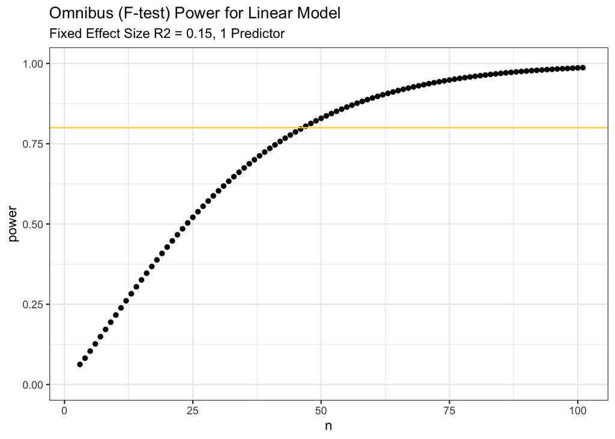

```r
ggplot(data = OLSReg_df) +
  theme_bw() +
  aes(x = n, y = power) +
  labs(
    title = "Omnibus (F-test) Power for Linear Model",
    subtitle = "Fixed Effect Size R2 = 0.15, 1 Predictor"
  ) +
  scale_y_continuous(limits = c(0, 1)) +
  geom_point() +
  geom_abline(slope = 0, intercept = 0.8, colour = "gold")
```

Given the graph, we notice that we need an approximate sample size or n of close to 50 to detect a medium effect size in an OLS Regression.

The following is a power analysis for a univariate OLS regression given a fixed sample size. We will create a sequence of effect sizes that capture Cohen’s guidelines as well as the effect size of 0.75 of our sample regression. Our fixed n will be n = 32 as the sample.

```r
OLSRegN_df <- tibble(R2 = seq(0, 0.75, length.out = 100))

OLSRegN_df$power <- map_dbl(
  .x = OLSRegN_df$R2,
  .f = ~{
    out2_ls <- pwrss.f.reg(
      # "Effect size" of a linear model
      r2 = .x,
      # number of predictors
      k = 1,
      # sample size
      n = 32,
      power = NULL,
      alpha = 0.05,
      # Stop printing messages
      verbose = FALSE
    )
    out2_ls$power
  }
)
```

The following is the power curve for a fixed sample size of n = 32

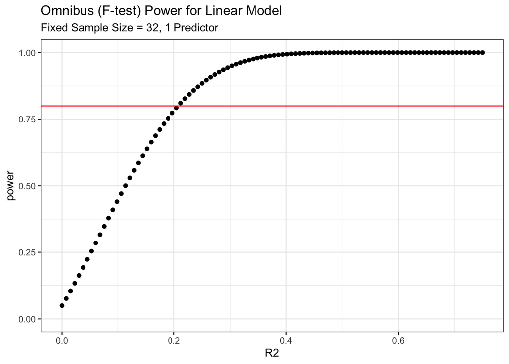

```r
ggplot(data = OLSRegN_df) +
  theme_bw() +
  aes(x = R2, y = power) +
  labs(
    title = "Omnibus (F-test) Power for Linear Model",
    subtitle = "Fixed Sample Size = 32, 1 Predictor"
  ) +
  scale_y_continuous(limits = c(0, 1)) +
  geom_point() +
  geom_abline(slope = 0, intercept = 0.8, colour = "red")
```

Given the graph, we notice that given n = 32, a power of 80% and higher is achieved when the effect size is at least approximately r2 = 0.20.

## 23.2 The `pwr.f2.test` function

Power analysis using the `pwr.f2.test`: where, u = 1, The F numerator degrees of freedom (u=1) or the number of coefficients(independent variables) in the model

and we will use Cohen’s criteria for effect sizes and first provide analyses for a medium effect size of 0.15 [<sup>3</sup>]<sup>4</sup><sup>5</sup>

```r
# Using Cohen 1988 criteria, where,
#f2 = 0.02 small effect;
#f2 = 0.15 medium effect;
#f2 = 0.35 indicates a large effect

### Fixed Effect size f2 = 0.15###
# n = 50
pwr.f2.test(
  u = 1,
  v = 50 - 1 - 1,
  f2 = .15,
  sig.level = 0.05,
  power = NULL
  )

     Multiple regression power calculation

              u = 1
              v = 48
             f2 = 0.15
      sig.level = 0.05
          power = 0.765
# n = 25
pwr.f2.test(
  u = 1,
  v = 25 - 1 - 1,
  f2 = 0.15,
  sig.level = 0.05,
  power = NULL
  )

     Multiple regression power calculation

              u = 1
              v = 23
             f2 = 0.15
      sig.level = 0.05
          power = 0.458
# n = 12
pwr.f2.test(
  u = 1,
  v = 12 - 1 - 1,
  f2 = 0.15,
  sig.level = 0.05,
  power = NULL
  )

     Multiple regression power calculation

              u = 1
              v = 10
             f2 = 0.15
      sig.level = 0.05
          power = 0.229
```

Now, we will explore a fixed n = 32

```r
# ES = .02, r = .14
pwr.f2.test(
  u = 1,
  v = 32 - 1 - 1,
  f2 = .02,
  sig.level = 0.05,
  power = NULL
  )

     Multiple regression power calculation

              u = 1
              v = 30
             f2 = 0.02
      sig.level = 0.05
          power = 0.121
# ES = 0.15, r = .39
pwr.f2.test(
  u = 1,
  v = 32 - 1 - 1,
  f2 = 0.15,
  sig.level = 0.05,
  power = NULL
  )

     Multiple regression power calculation

              u = 1
              v = 30
             f2 = 0.15
      sig.level = 0.05
          power = 0.564
# ES = .35, r = .59
pwr.f2.test(
  u = 1,
  v = 32 - 1 - 1,
  f2 = 0.35,
  sig.level = 0.05,
  power = NULL
  )

     Multiple regression power calculation

              u = 1
              v = 30
             f2 = 0.35
      sig.level = 0.05
          power = 0.899
```

We will now look at the 3 types of effect sizes given various sample sizes

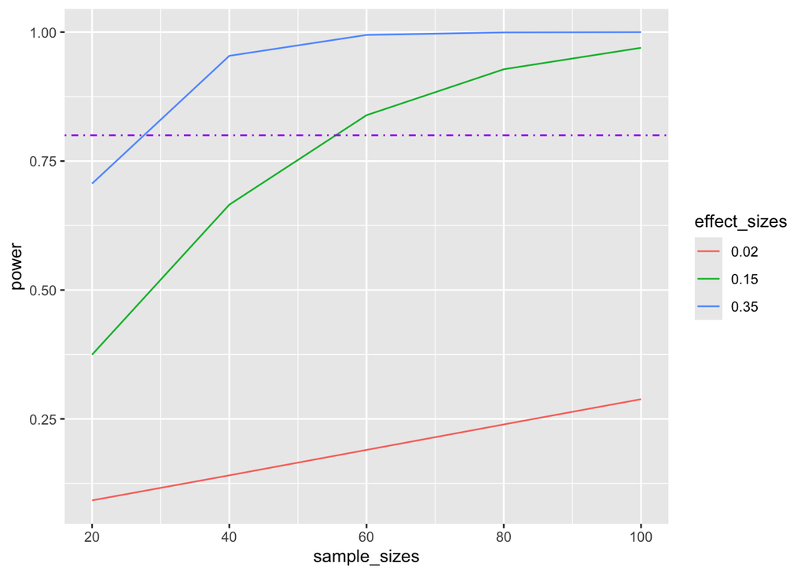

```r
effect_sizes <- c(0.02, 0.15, 0.35)
sample_sizes = seq(20, 100, 20)

input_df <- crossing(effect_sizes,sample_sizes)
glimpse(input_df)
Rows: 15
Columns: 2
$ effect_sizes <dbl> 0.02, 0.02, 0.02, 0.02, 0.02, 0.15, 0.15, 0.15, 0.15, 0.1…
$ sample_sizes <dbl> 20, 40, 60, 80, 100, 20, 40, 60, 80, 100, 20, 40, 60, 80,…

get_power <- function(df){
  power_result <- pwr.f2.test(
    u = 1,
    v = df$sample_sizes - 1 - 1,
    f2 = df$effect_sizes,
    )
  df$power=power_result$power
  return(df)
}

# run get_power for each combination of effect size
# and sample size

power_curves <- input_df %>%
  do(get_power(.)) %>%
  mutate(effect_sizes = as.factor(effect_sizes))


ggplot(power_curves,
       aes(x=sample_sizes,
           y=power,
           color=effect_sizes)
       ) +
  geom_line() +
  geom_hline(yintercept = 0.8,
             linetype='dotdash',
             color = "purple")
```

## 23.3 The `wp.regression` function

Lastly, we use the `wp.regression` function to examine the appropriate sample size given an effect size of 0.15 to achieve a power of 80% or higher [<sup>6</sup>]<sup>7</sup>

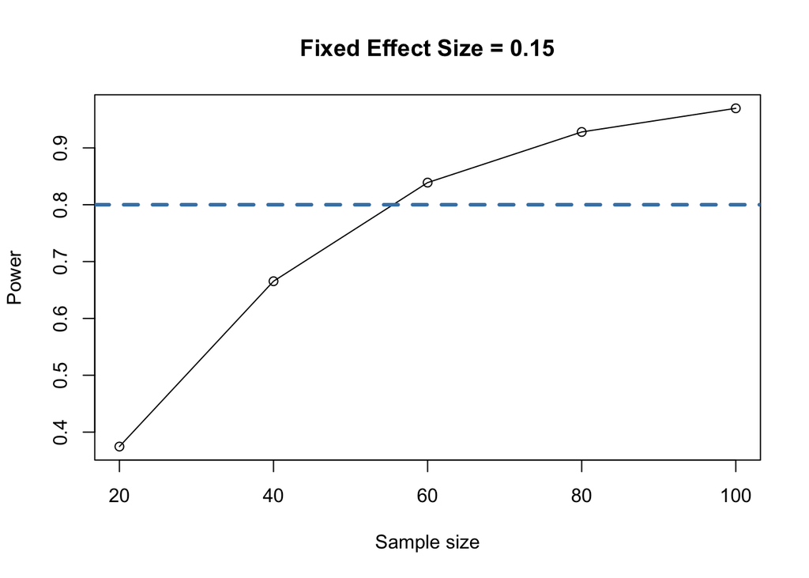

```
integer(0)
```

```r
# Using webpower
#p1 = 1
### Fixed ES = 0.15 ###
res <- wp.regression(n = seq(20,100,20),
                     p1 = 1,
                     f2 = 0.15,
                     alpha = 0.05,
                     power = NULL
                    )
res
Power for multiple regression

      n p1 p2   f2 alpha power
     20  1  0 0.15  0.05 0.375
     40  1  0 0.15  0.05 0.665
     60  1  0 0.15  0.05 0.839
     80  1  0 0.15  0.05 0.928
    100  1  0 0.15  0.05 0.970

URL: http://psychstat.org/regression
plot(res,  main = "Fixed Effect Size = 0.15")+
abline(a = .80, b = 0, col = 'steelblue', lwd = 3, lty = 2)
```

The results are similar to the previous functions. However, in this function, given an effect size of 0.15, we need an n of close to 60 to achieve 80% power.

```r
# Using webpower
#p1 = 1
### Fixed n = 50 ###
res <- wp.regression(n = 50,
                     p1 = 1,
                     f2 = seq(0.00, 0.35, 0.05),
                     alpha = 0.05,
                     power = NULL
                    )
res
Power for multiple regression

     n p1 p2   f2 alpha power
    50  1  0 0.00  0.05 0.050
    50  1  0 0.05  0.05 0.341
    50  1  0 0.10  0.05 0.591
    50  1  0 0.15  0.05 0.765
    50  1  0 0.20  0.05 0.873
    50  1  0 0.25  0.05 0.934
    50  1  0 0.30  0.05 0.967
    50  1  0 0.35  0.05 0.984

URL: http://psychstat.org/regression
```

# References

1.

Cohen J. Statistical power analysis for the behavioral sciences. 2nd ed. Hillsdale, N.J: L. Erlbaum Associates; 1988.

2.

A practical guide to statistical power and sample size calculations in r [Internet]. Available from: https://cran.r-project.org/web/packages/pwrss/vignettes/examples.html#3_Linear_Regression_(F_and_t_Tests)

3.

Cohen J. Statistical power analysis for the behavioral sciences. 2nd ed. Hillsdale, N.J: L. Erlbaum Associates; 1988.

4.

Power in r | [Internet]. Available from: https://blogs.uoregon.edu/rclub/2015/11/10/power-in-r/

5.

Statistical power analysis - jacob cohen, 1992 [Internet]. Available from: https://journals.sagepub.com/doi/10.1111/1467-8721.ep10768783

6.

Zhang Z, Wang L. Advanced statistics using r [Internet]. ISDSA Press; 2017. Available from: https://advstats.psychstat.org/

7.

Wp.regression: Statistical power analysis for linear regression in WebPower: Basic and advanced statistical power analysis [Internet]. Available from: https://rdrr.io/cran/WebPower/man/wp.regression.html